# 2019 Fordgo Bike Data Exploration

## by Long Nguyen

## Investigation Overview

> In this project, I want to investigate the relationship between trip duration and bikers' age/start day based on users' types and their gender.

## Dataset Overview

> This data set includes information about individual rides made in a bike-sharing system covering the greater San Francisco Bay area

> The dataset consists of 183412 trips recorded on February and March 2019.

## Member's age vs Trip Duration(s) by User Types

> The visualization supported my hypothesis that younger people would spend more time on a bike trip. The plot showed that a typical riders would be in their 30s. There is no difference between type of users

```
Text(0,0.5,'Duration(s)')
```

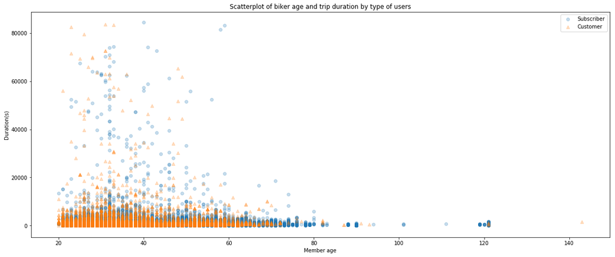

```python
cat_markers = [['Subscriber', 'o'], ['Customer', '^']]
plt.figure(figsize=[20, 8])
for cat, marker in cat_markers:
    df_cat = df[df['user_type'] == cat]
    plt.scatter(data = df_cat, x = 'member_age', y = 'duration_sec', marker = marker,alpha = 0.25)
plt.legend(['Subscriber','Customer'])
plt.title('Scatterplot of biker age and trip duration by type of users')
plt.xlabel('Member age')
plt.ylabel('Duration(s)')
```

## Member's age vs Trip Duration(s) by Gender

> Most bikers of 3 genders type are around their 30s spending more time on the trip than others. From visualization, I find out that the outlier 143 is a female rider (I won't be removing it)

```
Text(0.5,0.98,'Scatterplot of biker age and trip duration by genders')
```

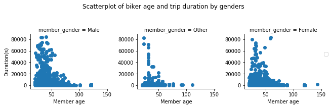

```python
g = sb.FacetGrid(data = df, col = 'member_gender')
g.map(plt.scatter, 'member_age', 'duration_sec')
g.set_xlabels('Member age')
g.set_ylabels('Duration(s)')
g.add_legend()
g.fig.subplots_adjust(top=0.7)
g.fig.suptitle('Scatterplot of biker age and trip duration by genders')
```

## Start Day vs Trip Duration(s) by User Types

> Customers spend more time on the trip than subscribers and most on weekend. This result is surprising

> People spend more time bike riding during weekend

```
Text(0,0.5,'Duration(s)')
```

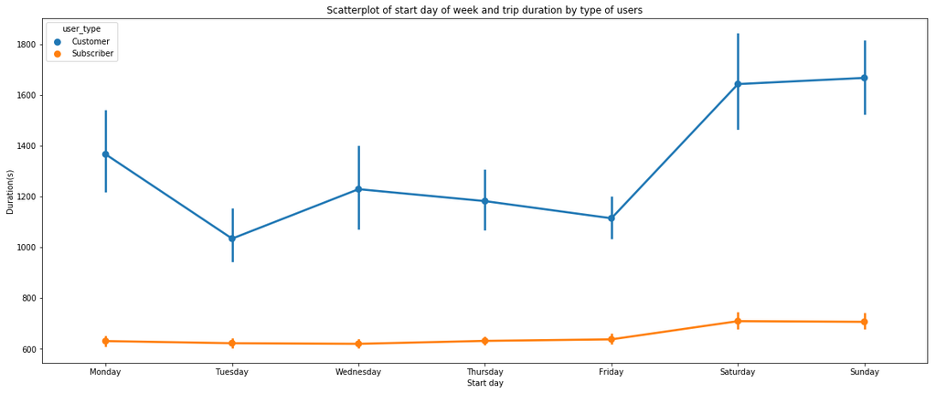

```python
plt.figure(figsize=[20, 8])
order = ["Monday", "Tuesday", "Wednesday", "Thursday", "Friday", "Saturday","Sunday"]
sb.pointplot(data = df, x = 'start_time_day', y = 'duration_sec', hue='user_type', order=order)
plt.title('Scatterplot of start day of week and trip duration by type of users')
plt.xlabel('Start day')
plt.ylabel('Duration(s)')
```

## Start Day vs Trip Duration(s) by Gender

> The visualization shows quite a surprising result with others spend the most time on the trip while male bikers spend the least time on the trip

> Trip duration for all riders are longer on weekends

```
Text(0,0.5,'Duration(s)')
```

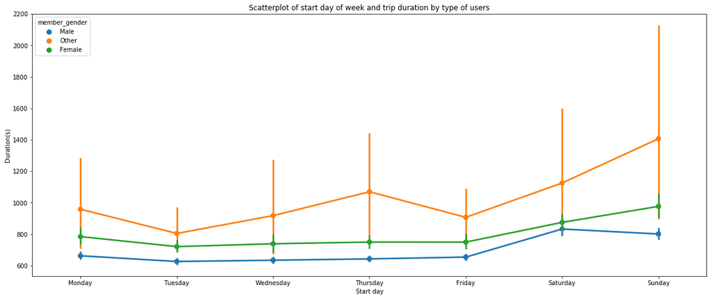

```python
plt.figure(figsize=[20, 8])
order = ["Monday", "Tuesday", "Wednesday", "Thursday", "Friday", "Saturday","Sunday"]
sb.pointplot(data = df, x = 'start_time_day', y = 'duration_sec', hue='member_gender', order=order)
plt.title('Scatterplot of start day of week and trip duration by type of users')
plt.xlabel('Start day')
plt.ylabel('Duration(s)')
```